# Ames Housing Dataset Regression Analysis

Author

Lucas McGill

Published

November 13, 2025

## Introduction

**Objective:** Develop a multiple linear regression model to predict `SalePrice` using relevant predictor variables, demonstrating iterative model improvement and proper documentation of the prompt engineering process with a Large Language Model (LLM).

## Step One: Description of Data

### Data Loading and Initial Exploration

*Prompt 10: Load the Ames Housing dataset and show me the structure and dimensions of the data.*

```r
# Load the housing data
housing <- read.csv("amesHousing2011.csv")

# View first few rows
head(housing)
```

```
  Order       PID MSSubClass MSZoning LotFrontage LotArea Street Alley LotShape
1  1498 908154080         20       RL         123   47007   Pave  <NA>      IR1
2  2738 905427030         75       RL          60   19800   Pave  <NA>      Reg
3  2446 528320060         60       RL         118   35760   Pave  <NA>      IR1
4  2667 902400110         75       RM          90   22950   Pave  <NA>      IR2
5  2451 528360050         60       RL         114   17242   Pave  <NA>      IR1
6  1307 902207220         75       RM          87   18386   Pave  <NA>      Reg
  LandContour Utilities LotConfig LandSlope Neighborhood Condition1 Condition2
1         Lvl    AllPub    Inside       Gtl      Edwards       Norm       Norm
2         Lvl    AllPub    Inside       Gtl      Edwards       Norm       Norm
3         Lvl    AllPub   CulDSac       Gtl      NoRidge       Norm       Norm
4         Lvl    AllPub    Inside       Gtl      OldTown     Artery       Norm
5         Lvl    AllPub    Inside       Gtl      NoRidge       Norm       Norm
6         Lvl    AllPub    Inside       Gtl      OldTown       Norm       Norm
  BldgType HouseStyle OverallQual OverallCond YearBuilt YearRemod.Add RoofStyle
```

[output cut: 69 more lines]

```r
# Check dimensions
cat("Dataset dimensions:", nrow(housing), "rows and", ncol(housing), "columns\n")
```

```
Dataset dimensions: 2925 rows and 82 columns
```

```r
# View structure of the dataset
str(housing)
```

```
'data.frame':   2925 obs. of  82 variables:
 $ Order        : int  1498 2738 2446 2667 2451 1307 1538 2195 2331 16 ...
 $ PID          : int  908154080 905427030 528320060 902400110 528360050 902207220 909282030 909176080 527210040 527216070 ...
 $ MSSubClass   : int  20 75 60 75 60 75 50 190 60 60 ...
 $ MSZoning     : chr  "RL" "RL" "RL" "RM" ...
 $ LotFrontage  : int  123 60 118 90 114 87 NA 60 60 47 ...
 $ LotArea      : int  47007 19800 35760 22950 17242 18386 14100 10896 18062 53504 ...
 $ Street       : chr  "Pave" "Pave" "Pave" "Pave" ...
 $ Alley        : chr  NA NA NA NA ...
 $ LotShape     : chr  "IR1" "Reg" "IR1" "IR2" ...
 $ LandContour  : chr  "Lvl" "Lvl" "Lvl" "Lvl" ...
 $ Utilities    : chr  "AllPub" "AllPub" "AllPub" "AllPub" ...
 $ LotConfig    : chr  "Inside" "Inside" "CulDSac" "Inside" ...
 $ LandSlope    : chr  "Gtl" "Gtl" "Gtl" "Gtl" ...
 $ Neighborhood : chr  "Edwards" "Edwards" "NoRidge" "OldTown" ...
```

[output cut: 68 more lines]

**R Code Explanation:** - `read.csv()` loads the CSV file into a data frame called `housing` - `head()` displays the first 6 rows to see what the data looks like - `nrow()` and `ncol()` show the number of rows (observations) and columns (variables) - `str()` shows the structure: variable names, types (numeric, character, etc.), and first few values

### Summary Statistics

*Prompt 11: Generate summary statistics for all variables in the dataset.*

```r
# Summary statistics for all variables
summary(housing)
```

```
     Order           PID              MSSubClass      MSZoning
 Min.   :   1   Min.   :5.263e+08   Min.   : 20.0   Length:2925
 1st Qu.: 732   1st Qu.:5.285e+08   1st Qu.: 20.0   Class :character
 Median :1463   Median :5.355e+08   Median : 50.0   Mode  :character
 Mean   :1465   Mean   :7.144e+08   Mean   : 57.4
 3rd Qu.:2199   3rd Qu.:9.072e+08   3rd Qu.: 70.0
 Max.   :2930   Max.   :1.007e+09   Max.   :190.0

  LotFrontage        LotArea          Street             Alley
 Min.   : 21.00   Min.   :  1300   Length:2925        Length:2925
 1st Qu.: 58.00   1st Qu.:  7438   Class :character   Class :character
 Median : 68.00   Median :  9428   Mode  :character   Mode  :character
 Mean   : 69.02   Mean   : 10104
 3rd Qu.: 80.00   3rd Qu.: 11515
 Max.   :313.00   Max.   :215245
 NA's   :490
   LotShape         LandContour         Utilities          LotConfig
 Length:2925        Length:2925        Length:2925        Length:2925
 Class :character   Class :character   Class :character   Class :character
 Mode  :character   Mode  :character   Mode  :character   Mode  :character




  LandSlope         Neighborhood        Condition1         Condition2
 Length:2925        Length:2925        Length:2925        Length:2925
 Class :character   Class :character   Class :character   Class :character
 Mode  :character   Mode  :character   Mode  :character   Mode  :character




   BldgType          HouseStyle         OverallQual      OverallCond
 Length:2925        Length:2925        Min.   : 1.000   Min.   :1.000
 Class :character   Class :character   1st Qu.: 5.000   1st Qu.:5.000
 Mode  :character   Mode  :character   Median : 6.000   Median :5.000
                                       Mean   : 6.088   Mean   :5.564
                                       3rd Qu.: 7.000   3rd Qu.:6.000
                                       Max.   :10.000   Max.   :9.000

```

[output cut: 112 more lines]

```
    MiscVal             MoSold           YrSold       SaleType
 Min.   :    0.00   Min.   : 1.000   Min.   :2006   Length:2925
 1st Qu.:    0.00   1st Qu.: 4.000   1st Qu.:2007   Class :character
 Median :    0.00   Median : 6.000   Median :2008   Mode  :character
 Mean   :   44.91   Mean   : 6.217   Mean   :2008
 3rd Qu.:    0.00   3rd Qu.: 8.000   3rd Qu.:2009
 Max.   :15500.00   Max.   :12.000   Max.   :2010

 SaleCondition        SalePrice
 Length:2925        Min.   : 12789
 Class :character   1st Qu.:129500
 Mode  :character   Median :160000
                    Mean   :180412
                    3rd Qu.:213500
                    Max.   :625000
```

### Exploring the Response Variable: Sale Price

*Prompt 12: Show me the distribution of SalePrice with a histogram and boxplot to identify outliers.*

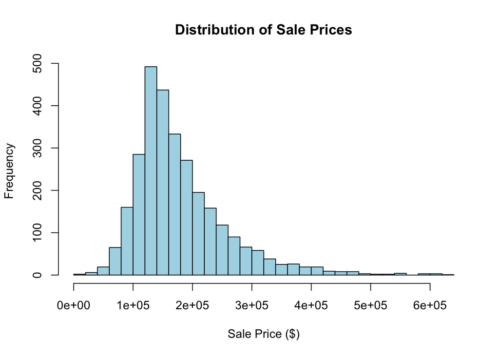

```r
# Histogram of Sale Price
hist(housing$SalePrice,
     breaks = 30,
     main = "Distribution of Sale Prices",
     xlab = "Sale Price ($)",
     col = "lightblue",
     border = "black")
```

```r
# Summary statistics for SalePrice
cat("\nSale Price Summary:\n")
```

```
Sale Price Summary:
```

```r
summary(housing$SalePrice)
```

```
   Min. 1st Qu.  Median    Mean 3rd Qu.    Max.
  12789  129500  160000  180412  213500  625000
```

```r
cat("\nStandard Deviation:", sd(housing$SalePrice), "\n")
```

```
Standard Deviation: 78554.86
```

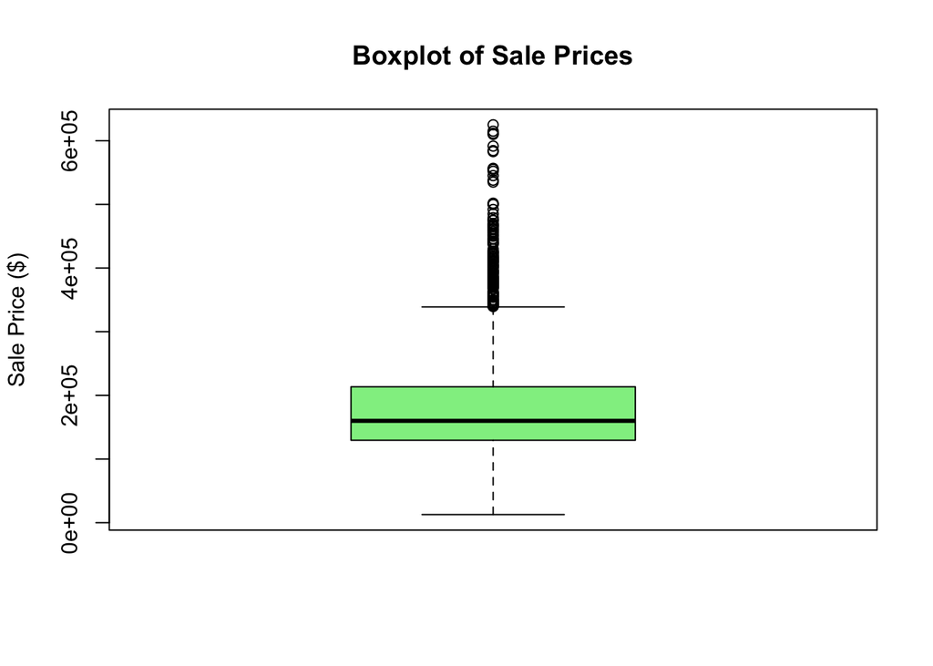

```r
# Boxplot to identify outliers
boxplot(housing$SalePrice,
        main = "Boxplot of Sale Prices",
        ylab = "Sale Price ($)",
        col = "lightgreen")
```

```r
# Identify potential outliers (above 95th percentile)
price_95 <- quantile(housing$SalePrice, 0.95)
cat("\n95th percentile of Sale Price: $", price_95, "\n")
```

```
95th percentile of Sale Price: $ 334000
```

```r
cat("Number of sales above 95th percentile:",
    sum(housing$SalePrice > price_95), "\n")
```

```
Number of sales above 95th percentile: 146
```

**R Code Explanation:** - `hist()` creates a histogram showing the distribution of sale prices - `breaks = 30` creates 30 bins for more detail - Right-skewed distribution expected (few expensive homes) - `boxplot()` visualizes outliers as points beyond the whiskers - `quantile()` calculates percentiles to identify outlier threshold - We identify homes above the 95th percentile as potential outliers (mansions)

**Observations:** - The distribution appears right-skewed with some high-value outliers - These outliers (mansion sales) may distort our regression model - Professor recommendation: Remove these outliers before modeling

### Exploring Key Predictor Variables

*Prompt 13: Show me distributions of the most important predictor variables: living area, overall quality, and year built.*

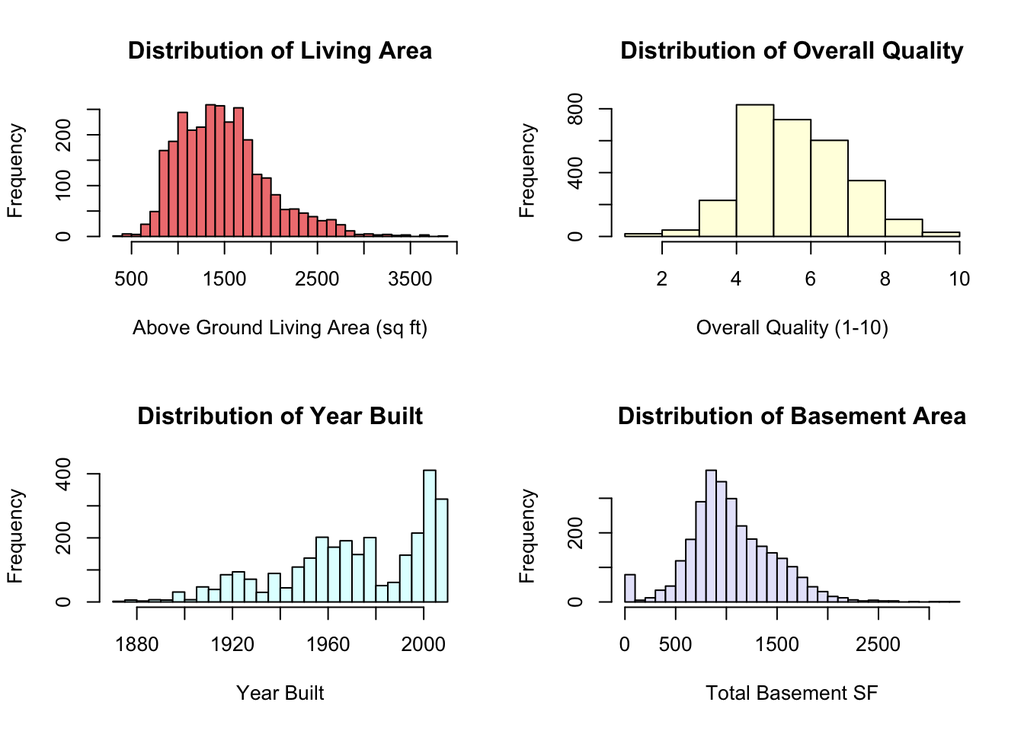

```r
# Living Area (GrLivArea)
par(mfrow = c(2, 2))  # Create 2x2 plot layout

hist(housing$GrLivArea,
     breaks = 30,
     main = "Distribution of Living Area",
     xlab = "Above Ground Living Area (sq ft)",
     col = "lightcoral")

# Overall Quality
hist(housing$OverallQual,
     breaks = 10,
     main = "Distribution of Overall Quality",
     xlab = "Overall Quality (1-10)",
     col = "lightyellow")

# Year Built
hist(housing$YearBuilt,
     breaks = 30,
     main = "Distribution of Year Built",
     xlab = "Year Built",
     col = "lightcyan")

# Total Basement Square Feet
hist(housing$TotalBsmtSF,
     breaks = 30,
     main = "Distribution of Basement Area",
     xlab = "Total Basement SF",
     col = "lavender")
```

```r
par(mfrow = c(1, 1))  # Reset to single plot

# Summary statistics for key predictors
cat("\nLiving Area Summary:\n")
```

```
Living Area Summary:
```

```r
summary(housing$GrLivArea)
```

```
   Min. 1st Qu.  Median    Mean 3rd Qu.    Max.
    334    1126    1441    1494    1740    3820
```

```r
cat("\nOverall Quality Summary:\n")
```

```
Overall Quality Summary:
```

```r
summary(housing$OverallQual)
```

```
   Min. 1st Qu.  Median    Mean 3rd Qu.    Max.
  1.000   5.000   6.000   6.088   7.000  10.000
```

```r
cat("\nYear Built Summary:\n")
```

```
Year Built Summary:
```

```r
summary(housing$YearBuilt)
```

```
   Min. 1st Qu.  Median    Mean 3rd Qu.    Max.
   1872    1954    1973    1971    2001    2010
```

**R Code Explanation:** - `par(mfrow = c(2, 2))` sets up a 2×2 grid to display 4 plots together - Each histogram shows the distribution of a key predictor variable - `par(mfrow = c(1, 1))` resets the plot layout back to single plots - Summary statistics help identify the range and central tendency

### Relationships Between Variables

*Prompt 14: Create scatterplots showing the relationship between SalePrice and key predictors.*

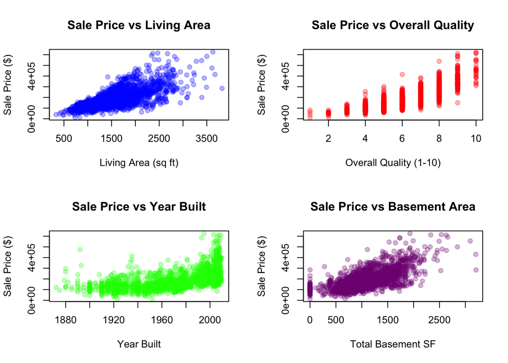

```r
# Set up 2x2 plot layout
par(mfrow = c(2, 2))

# SalePrice vs Living Area
plot(housing$GrLivArea, housing$SalePrice,
     main = "Sale Price vs Living Area",
     xlab = "Living Area (sq ft)",
     ylab = "Sale Price ($)",
     pch = 19,
     col = rgb(0, 0, 1, 0.3))  # Semi-transparent blue

# SalePrice vs Overall Quality
plot(housing$OverallQual, housing$SalePrice,
     main = "Sale Price vs Overall Quality",
     xlab = "Overall Quality (1-10)",
     ylab = "Sale Price ($)",
     pch = 19,
     col = rgb(1, 0, 0, 0.3))  # Semi-transparent red

# SalePrice vs Year Built
plot(housing$YearBuilt, housing$SalePrice,
     main = "Sale Price vs Year Built",
     xlab = "Year Built",
     ylab = "Sale Price ($)",
     pch = 19,
     col = rgb(0, 1, 0, 0.3))  # Semi-transparent green

# SalePrice vs Basement Area
plot(housing$TotalBsmtSF, housing$SalePrice,
     main = "Sale Price vs Basement Area",
     xlab = "Total Basement SF",
     ylab = "Sale Price ($)",
     pch = 19,
     col = rgb(0.5, 0, 0.5, 0.3))  # Semi-transparent purple
```

```r
par(mfrow = c(1, 1))  # Reset plot layout
```

**R Code Explanation:** - `plot(x, y)` creates scatterplots to visualize relationships - `pch = 19` uses filled circles as plot points - `rgb(r, g, b, alpha)` creates semi-transparent colors to see overlapping points - We’re looking for: - **Linear relationships**: Points form a straight line pattern - **Non-linear relationships**: Curved patterns (may need transformation) - **Heteroscedasticity**: Spread of points increases with X (funneling) - **Strength**: How tightly points cluster around a pattern

**Expected Observations:** - **Living Area**: Strong positive linear relationship expected - **Overall Quality**: Positive relationship, possibly non-linear (may need log transformation) - **Year Built**: Positive relationship, variance may increase with year (heteroscedasticity)

### Correlation Analysis

*Prompt 15: Calculate correlations between SalePrice and numeric predictors to identify the strongest relationships.*

```r
# Select key numeric variables
numeric_vars <- c("SalePrice", "GrLivArea", "OverallQual", "OverallCond",
                 "YearBuilt", "YearRemod.Add", "TotalBsmtSF", "X1stFlrSF",
                  "X2ndFlrSF", "BedroomAbvGr", "TotRmsAbvGrd",
                  "GarageCars", "GarageArea")

# Calculate correlation matrix
cor_matrix <- cor(housing[, numeric_vars], use = "complete.obs")

# Display correlations with SalePrice, sorted by absolute value
cor_with_price <- cor_matrix[, "SalePrice"]
cor_sorted <- sort(abs(cor_with_price), decreasing = TRUE)

cat("Correlations with Sale Price (sorted by strength):\n")
```

```
Correlations with Sale Price (sorted by strength):
```

```r
print(round(cor_sorted, 3))
```

```
    SalePrice   OverallQual     GrLivArea   TotalBsmtSF    GarageCars
        1.000         0.805         0.719         0.659         0.652
   GarageArea     X1stFlrSF     YearBuilt YearRemod.Add  TotRmsAbvGrd
        0.648         0.643         0.565         0.540         0.498
    X2ndFlrSF  BedroomAbvGr   OverallCond
        0.257         0.139         0.103
```

```r
cat("\n\nTop 10 correlations with SalePrice:\n")
```

```
Top 10 correlations with SalePrice:
```

```r
print(round(cor_with_price[names(cor_sorted)[1:10]], 3))
```

```
    SalePrice   OverallQual     GrLivArea   TotalBsmtSF    GarageCars
        1.000         0.805         0.719         0.659         0.652
   GarageArea     X1stFlrSF     YearBuilt YearRemod.Add  TotRmsAbvGrd
        0.648         0.643         0.565         0.540         0.498
```

**R Code Explanation:** - `cor()` calculates correlation coefficients between variables - `use = "complete.obs"` handles missing data by using only complete cases - Correlation ranges from -1 (perfect negative) to +1 (perfect positive) - Values close to 0 indicate weak or no linear relationship - `sort(abs(...))` sorts by absolute value to find strongest relationships regardless of direction

**Important Note from Professor:** Pairwise correlations can miss important relationships. For example, location variables may have mediating effects on other predictors that won’t show up in simple correlations.

### Missing Data Analysis

*Prompt 16: Identify which variables have missing data and how much.*

```r
# Count missing values per variable
missing_counts <- colSums(is.na(housing))

# Show only variables with missing data
vars_with_missing <- missing_counts[missing_counts > 0]

if (length(vars_with_missing) > 0) {
  cat("Variables with missing data:\n")

  # Calculate percentage missing
  missing_pct <- 100 * vars_with_missing / nrow(housing)

  # Create summary data frame
  missing_summary <- data.frame(
    Variable = names(vars_with_missing),
    Count = vars_with_missing,
    Percentage = round(missing_pct, 2)
  )

  # Sort by count
  missing_summary <- missing_summary[order(-missing_summary$Count), ]

  print(missing_summary, row.names = FALSE)
} else {
  cat("No missing data detected in the dataset.\n")
}
```

```
Variables with missing data:
     Variable Count Percentage
       PoolQC  2914      99.62
  MiscFeature  2820      96.41
        Alley  2727      93.23
        Fence  2354      80.48
  FireplaceQu  1422      48.62
  LotFrontage   490      16.75
  GarageYrBlt   159       5.44
   GarageQual   158       5.40
   GarageCond   158       5.40
   GarageType   157       5.37
 GarageFinish   157       5.37
     BsmtQual    79       2.70
     BsmtCond    79       2.70
 BsmtExposure    79       2.70
 BsmtFinType1    79       2.70
 BsmtFinType2    79       2.70
   MasVnrArea    23       0.79
 BsmtFullBath     2       0.07
 BsmtHalfBath     2       0.07
   BsmtFinSF1     1       0.03
   BsmtFinSF2     1       0.03
    BsmtUnfSF     1       0.03
  TotalBsmtSF     1       0.03
   GarageCars     1       0.03
   GarageArea     1       0.03
```

```r
# Total missing values
cat("\nTotal missing values in dataset:", sum(is.na(housing)), "\n")
```

```
Total missing values in dataset: 13944
```

**R Code Explanation:** - `is.na()` returns TRUE for missing values - `colSums()` counts missing values for each column - We calculate both counts and percentages to assess severity - Variables with >20% missing may need to be excluded - Variables with <5% missing can use simple imputation - **Professor recommendation**: Use multiple imputation instead of simple median imputation

### Summary of Key Findings

**Next Steps**: Proceed to Step Two - data preprocessing and regression modeling.